# 18- Pipes

Augusto de Souza Cavalcanti

05/05/2021

# 18 Pipes

## 18.1 Introduction

Pipes são úteis para expressar claramente uma sequência de operações. A partir de agora vamos entender como eles funcionam e alternativas a eles e ferramentas úteis relacionadas.

O pipe vem do pacote magrittr. O tidyverse carrega o pipe automaticamente mas nesse cápitulo vamos focar em pipes então carregar apenas o magrittr.

## 18.2.4 The pipe

O pipe transforma de uma lingugem léxica para uma computacional, fazendo uma transformação no ordem e alterando as coisas. A maneira que ele funciona implica que temos algumas funções que não vão funcionar.

O pipe transforma o que você escreveu e cria uma função fazendo o processo que pedimos num abiente sem ser o global, mas sim o local, das funções.

Funções que usam o ambiente atual. Ex: Assign()

```r
assign("x",10)
x
```

```
## [1] 10
```

```r
"x" %>% assign(20)
x
```

```
## [1] 10
```

Funções que usam avaliação preguiçosa. No r os argumentos só são computados quando a função usa eles, não antes de chamar a função. No entanto o pipe computa cada elemento, dessa maneira funções podem não funcionar com esse comportamento.

Um exemplo desse problema é na função é tryCatch(), que permite que capturemos e lidar com erros.

## 18.3 When not to use the pipe

Pipes são úteis mas nem sempre são necessários e não são a única ferramenta disponível. Eles são mais úteis para escrever uma sequência curta e linear de operações.

- Quando seus pipes são mais longos que dez passos (por exemplo). Nesse caso vale a pena criar um objeto intermediário. Faz a debugação ficar mais simples e torna seu código mais legível.
- Quando temos múltiplos inputs e outputs. Se tem um objeto primário sendo transformado, mas dois objetos intermediarios sendo combinados não use o pipe.

## 18.4 Other tools from magrittr

Todos pacotes do tidyverse tem o pipe implementado mas o magrittr tem outras ferramentas que podem ser usadas:

Muitas vezes é importante chma os side-effects de uma função quando trabalhando com pipes complexos. Muitas funções não retornam nada, para funções que funcionam assim temos que usar %T% que retorna o objeto da esquerda não o da direita. Como abaixo.

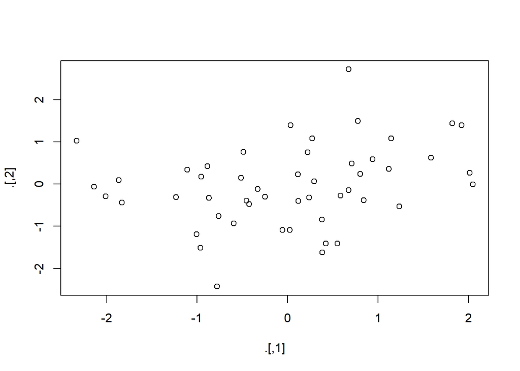

```r
rnorm(100) %>%
  matrix(ncol = 2) %>%
  plot() %>%
  str()
```

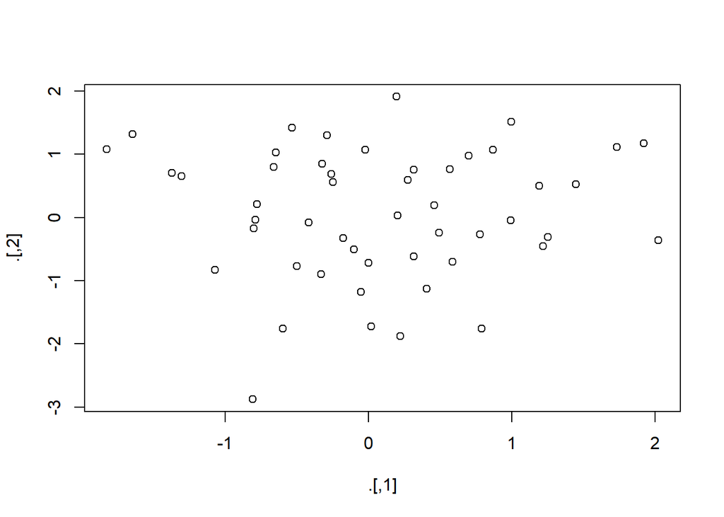

```
##  num [1:50, 1:2] -0.0525 2.0239 0.2754 1.2184 -0.646 ...
```

```r
rnorm(100) %>%
  matrix(ncol = 2) %T>%
  plot() %>%
  str()
```

Se estiver trabalhando com funções que não tem que não tem uma API baseada em df. Ou seja temos que passar vetores, não o dataframe. Pode ser útil usar %$%. Ele remove as variáveis do formato df para poderem ser usadas explicitamente.

```r
mtcars %$%
  cor(disp, mpg)
```

```
## [1] -0.8475514
```

Para atribuição o magrittr permite que usemos %<>%, que permite que substituamos códigos como:

```r
mtcars <- mtcars %>%
  transform(cyl = cyl * 2)
```

por:

```r
mtcars %<>% transform(cyl = cyl * 2)
```